# Supplementary Materials: Registered Analysis

ADF Clarke and AE Hughes

# 1 Intro

This file contains the *registered analysis* for Hughes et al. (2023). This file requires the following:

`1_pre_process_data.R` : this script imports the data and applies our registered exclusion criteria.

As some of the Bayesian models take a while to fit, these are pre-computed using `2_fit_models.R`. Similarly, please run `2b_model_comparison` to recompute the posterior model weights for H1 and H2.

`../scripts/our_functions.R` contains a range of functions for working with the model objects.

## 1.1 Setup and Data Import

```r
# set ggplot2 theme
theme_set(ggthemes::theme_tufte())

colourPalette <- c("#e78429", "#ed968c", "#7c4b73","#aadce0", "#72bcd5", "528fad") # this matches experimental stuff
colourPalette2 <- c("#648FFF", "#785EF0", "#DC267F","#FE6100", "#FFB000", "#000000") # this doesn't (colour blind friendly)

# use parallel cores for mcmc chains!
options(mc.cores = 4)

# reduce the number of decimal places
options(digits = 3)

# functions used for our Bayesian re-analysis
source("../scripts/our_functions.R")

# set seed to make sure everything is reproducible
set.seed(100320021)
```

## 1.2 Import and Remove Outliers

We will import data from the experiment (with pre-processing already in place, e.g. incorrect trials removed, 1st and 100th percentile reaction times removed) - see `1_pre_process_data.R` for details. $d1$ is the training data set (Experiment 1) and $d2$ is the test data set (Experiment 2).

```r
source("1_pre_process_data.R")

summary(d1)
```

```
##     observer         feature         trial            nd             rt
##  07     :  717   orange  :4405   Min.   :   1   Min.   : 0.0   Min.   :0.452
##  30     :  715   purple  :4470   1st Qu.: 367   1st Qu.: 1.0   1st Qu.:0.620
##  38     :  715   pink    :4470   Median : 830   Median : 4.0   Median :0.735
##  11     :  711   diamond :4493   Mean   : 821   Mean   :10.6   Mean   :0.796
##  04     :  707   triangle:4359   3rd Qu.:1290   3rd Qu.:19.0   3rd Qu.:0.901
##  34     :  707   circle  :4499   Max.   :1600   Max.   :31.0   Max.   :1.923
##  (Other):22424
##      block           lnd       ring
##  Min.   :1.00   Min.   :0.00   1:8991
##  1st Qu.:2.00   1st Qu.:0.69   2:9495
##  Median :3.00   Median :1.61   3:8210
##  Mean   :3.07   Mean   :1.84
##  3rd Qu.:5.00   3rd Qu.:3.00
##  Max.   :5.00   Max.   :3.47
##
```

```r
summary(d2)
```

```
##     observer       feature1           feature2             trial
##  38     : 1076   Length:40283       Length:40283       Min.   :   1
##  07     : 1075   Class :character   Class :character   1st Qu.: 411
##  14     : 1075   Mode  :character   Mode  :character   Median : 777
##  22     : 1073                                         Mean   : 780
##  06     : 1065                                         3rd Qu.:1145
##  36     : 1065                                         Max.   :1600
##  (Other):33854
##        nd             rt            block           lnd       ring
##  Min.   : 0.0   Min.   :0.452   Min.   :1.00   Min.   :0.00   1:13162
##  1st Qu.: 1.0   1st Qu.:0.587   1st Qu.:2.00   1st Qu.:0.69   2:11992
##  Median : 9.0   Median :0.671   Median :3.00   Median :2.30   3:15129
##  Mean   :10.7   Mean   :0.718   Mean   :2.94   Mean   :1.85
##  3rd Qu.:19.0   3rd Qu.:0.792   3rd Qu.:4.00   3rd Qu.:3.00
##  Max.   :31.0   Max.   :1.922   Max.   :5.00   Max.   :3.47
##
```

# 2 Fit Models to Data

For hypothesis 1, we fit the following models:

- A shifted lognormal model to the training data
- A lognormal model to the training data
- A normal model to the training data

For hypothesis 2, we fit the following models:

- A shifted lognormal model to the training data, with a linear number of distractors

For hypotheses 3 and 4, we fit the following models:

- A shifted lognormal model to the test data
- A shifted lognormal model to the test data with person as a fixed effect, as we want to predict person-level effects

The models take a little while to run, so do not run by default in this document. Set $eval=TRUE$ to run them.

Note that our approach differs slightly from the original methods proposed by Buetti et al (2019). In their manuscript, due to the between-subjects nature of the design, $a$ was calculated at the level of each sub-experiment. However, in our within-subjects version, we will use $a$ from the single feature experiments (i.e. Experiment 1) to predict $a$ in the compound feature experiments (i.e. Experiment 2).

```r
#source("2_fit_models.R")
```

## 2.1 Plotting prior predictions

From Figure 2.1, we can see that the priors chosen for our models centre the estimates of $D$ around 0 (i.e. we are not making any assumptions about what we expect the slopes to be).

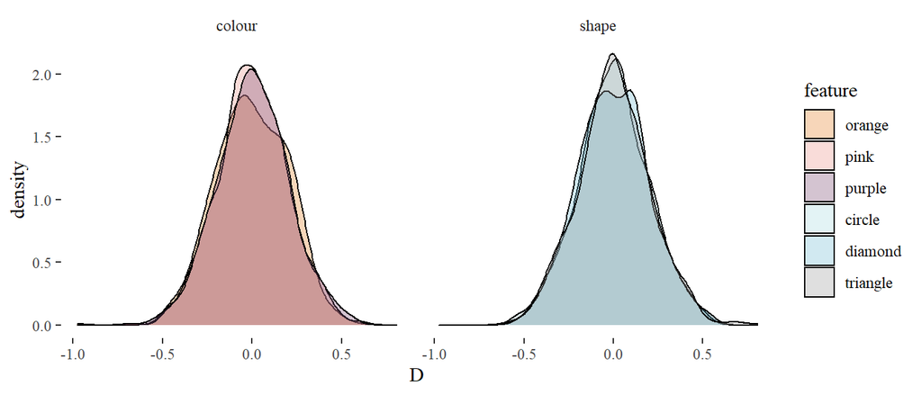

Figure 2.1: Prior predictions for our models.

```r
m1b <- readRDS("exp1_prior.model")

samples1b <- get_slopes(m1b, n = 1000)

samples1b %>% mutate(feature_type = if_else(
  feature %in% c("purple", "orange", "pink"), "colour", "shape")) %>%
  ggplot(aes(D, fill = feature)) +
  geom_density(alpha = 0.33) +
  facet_wrap(~feature_type) +
  scale_fill_manual(values=colourPalette, limits = c("orange", "pink","purple", "circle", "diamond", "triangle"))
```

## 2.2 Hypothesis 1

Here, we test whether using a shifted-lognormal distribution gives a better model fit than using a lognormal or normal distribution. We do this by calculating the marginal likelihood of the relevant models, and then calculating the posterior probabilities. This gives us a probability for each model that represents the likelihood that the model gives the best prediction. Please see `2b_model_comparison.R` for the code for this model comparison - here, we report the LOO and WAIC values for each model in the model comparison. These are broadly comparable measures: LOO (leave one out cross validation) is an estimate of the out-of-sample predictive fit, and WAIC (widely applicable information criterion) is a Bayesian criterion for estimating out-of-sample expectation.

The shifted lognormal model gives the best prediction 100% of the time, meaning that we have strong evidence that we should prefer this model over the others.

```r
m_sft <- readRDS("exp1.model")
m_nrl <- readRDS("exp1_normal.model")
m_log <- readRDS("exp1_lognormal.model")

# read in table and kable
hyp_1_table <- read_csv('model_comp_hyp1.csv')
knitr::kable(hyp_1_table) %>%
    kable_styling()
```

| model | LOO | WAIC |
| --- | --- | --- |
| shifted lognormal | 1 | 1 |
| normal | 0 | 0 |
| lognormal | 0 | 0 |

The code below allows for model checking - set $eval=TRUE$ if you want to look at the trace plots and summary statistics.

```r
# for model checking purposes

# shifted lognormal model
summary(m_sft)
plot(m_sft)

# normal model
summary(m_nrl)
plot(m_nrl)

# lognormal model
summary(m_log)
plot(m_log)
```

Figure 2.2 displays plots that show the model predictions for the different model types.

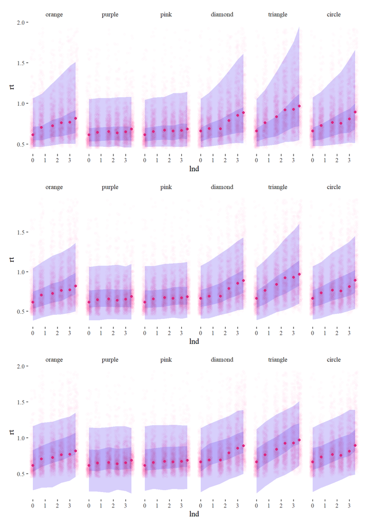

Figure 2.2: Model predictions for (top) shifted log normal model, (middle) log normal model and (bottom) normal model.

## 2.3 Hypothesis 2

Here, we want to verify that using log(number of distractors) in our model is superior to n(distractors). We use the same methods as for Hypothesis 1 above - and again, the code for the model comparison is available in `2b_model_comparison.R`.

| model | LOO | WAIC |
| --- | --- | --- |
| loglinear in n | 1 | 1 |
| linear in n | 0 | 0 |

Our loglinear model is preferred 100% of the time, supporting the hypothesis that this is the best model structure for the data.

# 3 Hypothesis 3

## 3.1 Fixed effect of D (group average)

In hypothesis 3, we are interested in testing which of the three models (collinear contrast integration, best feature guidance and orthogonal contrast combination) allows us to best predict $D$ in the double-feature data from the single-feature data.

First we will predict the group average D for each feature from the single-feature model. The table below shows these values, and shows that we have a good range of different D values for each of the single features. Figure 3.1 also shows these results visually.

```r
m1 <- readRDS("exp1.model")

samples1 <- get_slopes(m1)

samples1 %>% group_by(feature) %>%
  median_hdci(D) %>%
  select(feature, D, .lower, .upper) %>%
  knitr::kable()  %>%
  kable_styling()
```

| feature | D | .lower | .upper |
| --- | --- | --- | --- |
| circle | 0.191 | 0.175 | 0.204 |
| diamond | 0.187 | 0.171 | 0.205 |
| orange | 0.156 | 0.139 | 0.173 |
| pink | 0.042 | 0.028 | 0.057 |
| purple | 0.015 | 0.002 | 0.030 |
| triangle | 0.253 | 0.230 | 0.275 |

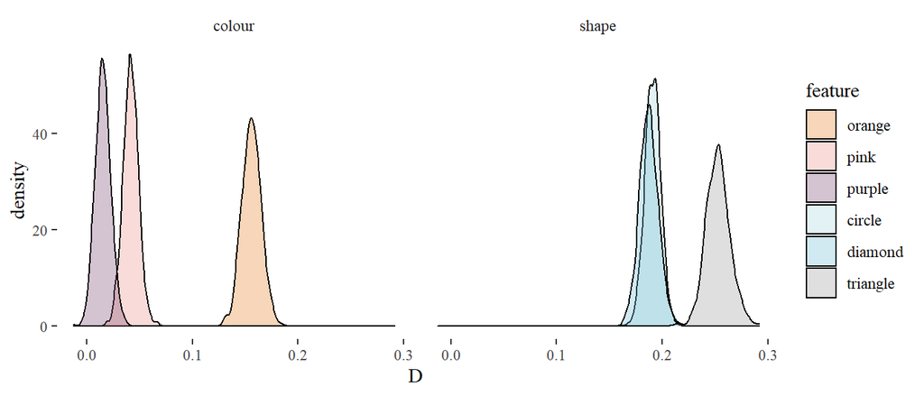

Figure 3.1: Predicting the group average D in Experiment 1.

```r
samples1 %>% mutate(feature_type = if_else(
  feature %in% c("purple", "orange", "pink"), "colour", "shape")) %>%
  ggplot(aes(D, fill = feature)) +
  geom_density(alpha = 0.33) +
  facet_grid(~feature_type) +
  scale_fill_manual(values=colourPalette,  limits = c("orange", "pink","purple", "circle", "diamond", "triangle")) -> pltDi

pltDi
```

In Figure 3.2 we show the group average $D$ values in Experiment 2 (i.e. the double-feature conditions). It seems that slope values are more affected by colour than shape, though it is possible to see differences (i.e. orange triangle has a higher slope than orange diamond or orange circle).

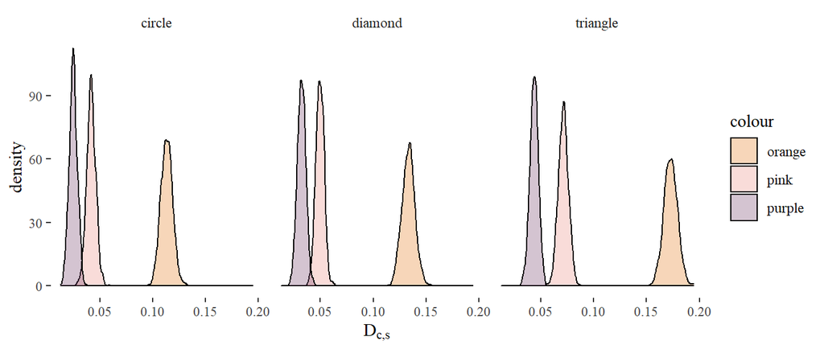

Figure 3.2: Predicting the group average D in Experiment 2.

```r
m2 <- readRDS("exp2_random.model")
samples2 <- get_slopes(m2)

#colourPalette2 <- c("#e78429", "#ed968c", "#7c4b73")

samples2 %>% separate(feature, into = c("colour", "shape")) %>%
  ggplot(aes(D, fill = colour)) +
  geom_density(alpha = 0.33) +
  facet_grid(.~shape) +
  scale_fill_manual(values=colourPalette) +
  xlab(expression(D["c,s"])) -> pltDcs

pltDcs
```

The code below allows for model checking for the Experiment 2 model - set eval=TRUE if you want to look at the trace plots and summary statistics.

```r
# model 2 - model checks
summary(m2)
plot(m2)
```

We now combine the single feature search slopes $D_c$ and $D_s$ to predict the double-feature conditions ($D_c,s$) using three different methods: collinear contrast integration, best feature guidance and orthogonal contrast combination. Figure 3.3 shows the predictions ($D_p$) from each model plotted against the empirical $D_e$ values. The best model would therefore be expected to fall along the 1:1 line with the predicted values closely matching the empirical ones.

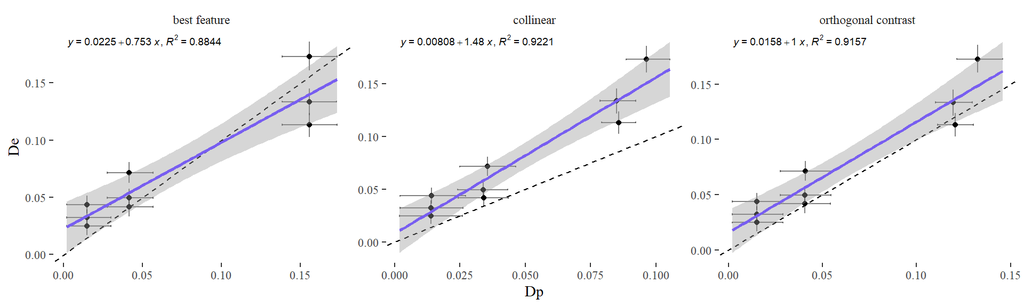

Figure 3.3: Predicted D plotted against empirical D for our pilot data.

```r
things_to_calc <- samples2 %>% select( -D, -.draw) %>%
  distinct() %>%
  separate(feature, c("feature1", "feature2"))

slopes <- pmap_df(things_to_calc, calc_D) %>%
  full_join(samples2, by = c(".draw", "feature")) %>%
  pivot_longer(c(collinear, `best feature`, `orthogonal contrast`), names_to = "method", values_to = "Dp") %>%
  select(-feature) %>%
  pivot_longer(c(D, Dp), names_to = "type", values_to = "D") %>%
  group_by(feature1, feature2, method, type)

slopes %>%
  median_hdci(D) %>%
  unite(D, D, .lower, .upper) %>%
  select(-.width, -.point, -.interval) %>%
  pivot_wider(names_from = "type", values_from = "D") %>%
  separate(D, into = c("De", "De_min", "De_max"), sep = "_", convert = TRUE) %>%
  separate(Dp, into = c("Dp", "Dp_min", "Dp_max"), sep = "_", convert=  TRUE) %>%
  ggplot(aes(x = Dp, xmin = Dp_min, xmax = Dp_max, y = De, ymin = De_min, ymax = De_max)) +
  geom_point() +
  geom_errorbar(alpha = 0.5) +
  geom_errorbarh(alpha = 0.5) +
  geom_abline(linetype = 2) +
  geom_smooth(method = "lm", fullrange  = T, colour = "#785EF0") +
      stat_poly_eq(formula = y ~ x,
               aes(label = paste(..eq.label.., ..rr.label.., sep = "*plain(\",\")~")),
               parse = TRUE, size = 2.5, label.y = 0.99, coef.digits = 3, rr.digits = 4) +
  facet_wrap(~method, scales = "free")
```

```r
ggsave("../../plots/Dpe.pdf", width = 7, height = 3)
```

We can then calculate mean absolute prediction error to allow us to say which model offers the best prediction of the empirical data:

```r
slopes  %>%
  ungroup() %>%
  pivot_wider(names_from = "type", values_from = "D") %>%
  mutate(abs_err = abs(D-Dp)) %>%
  group_by(feature1, feature2, method) %>%
  summarise(mean_abs_err = mean(abs_err)) %>%
  pivot_wider(names_from = "method", values_from = "mean_abs_err") %>%
  ungroup() -> slopes_err


add_row(slopes_err, feature1 = "sum", feature2 = "over all",
        `best feature` = sum(slopes_err[3]),
        collinear = sum(slopes_err[4]),
        `orthogonal contrast` = sum(slopes_err[5])) %>%
  knitr::kable() %>%
  kable_styling() %>%
  row_spec(10,bold=T,hline_after = T)
```

| feature1 | feature2 | best feature | collinear | orthogonal contrast |
| --- | --- | --- | --- | --- |
| orange | circle | 0.043 | 0.027 | 0.009 |
| orange | diamond | 0.023 | 0.048 | 0.014 |
| orange | triangle | 0.017 | 0.076 | 0.040 |
| pink | circle | 0.007 | 0.008 | 0.006 |
| pink | diamond | 0.009 | 0.016 | 0.010 |
| pink | triangle | 0.030 | 0.036 | 0.030 |
| purple | circle | 0.010 | 0.011 | 0.010 |
| purple | diamond | 0.017 | 0.018 | 0.017 |
| purple | triangle | 0.028 | 0.029 | 0.028 |
| sum | over all | 0.185 | 0.271 | 0.165 |

Overall, the orthogonal model has the lowest mean absolute error.

# 4 Hypothesis 4: Predicting Reaction Times

Finally, we test which model gives the best prediction of reaction times.

## 4.1 Original (Registered) Method

We begin with our original, registered method for testing hypothesis 4. Here, we use the posterior predictions from a model trained on the single-feature data to act as a prior for the double-feature data. (The function for this process is hidden from view, but can be found in the Markdown document, if you would like to view it).

Figure 4.1 shows predicted reaction times for the data, using orthogonal contrast combination. The other models are also computed in the hidden code, and can be visualised if desired.

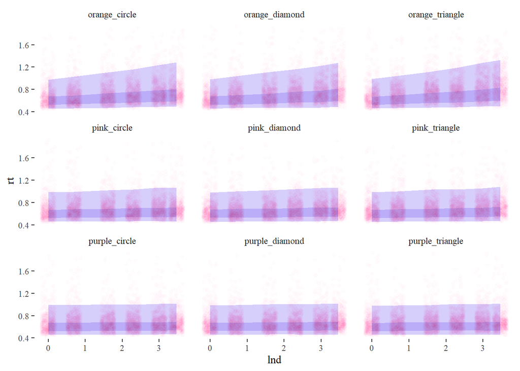

Figure 4.1: Predicted RTs for our data, using orthogonal contrast combination.

| model | posterior probability |
| --- | --- |
| collinear | 0.346 |
| best feature | 0.318 |
| orthogonal contrast | 0.336 |

All three models receive approximately the same predictive weight, meaning that we are not able to distinguish between them: we do not have evidence for one model over the others.

## 4.2 New, Improved (Unregistered) Method

We also document a second method for testing hypothesis 4 (this was not pre-registered). Here, we take $n = 100$ samples of the fixed effects from the model fitted to the single-feature data and the model fitted to the double-feature data. We replace the $D$ values in the double-feature model with the predicted $D$ values from using the single-feature model. The predicted mean $log(rt)$ is then calculated for each feature and number of distractors, and then compared to the empirical reaction times by calculating the absolute error.

First, we read in data and models again:

```r
source("../scripts/pred_rt_functions.R")
source("1_pre_process_data.R")

d1 %>% mutate(observer = as.numeric(observer)) %>%
  select(-nd) -> d1

d2 %>% mutate(observer = as.numeric(observer)) %>%
  select(-nd) -> d2

d2 %>% unite(feature, feature1, feature2) -> d2

m1 <- readRDS("exp1.model")
m2 <- readRDS("exp2_random.model")
```

We then merge the models i.e. adding the $D_p$ values to the double-feature model, and thwn use these to make predictions.

```r
ndraws <- 100

model1 <- get_rt_model_simple(m1)
rm(m1)
model2 <- get_rt_model_simple(m2)
rm(m2)

# convert in order to get D predictions for m2
full_join(
  mod_col <- model1 %>% filter(feature %in% c("orange", "pink", "purple")) %>%
    rename(feature1 = "feature", D1 = "D"),
  mod_sha <- model1 %>% filter(feature %in% c("circle", "diamond", "triangle")) %>%
    rename(feature2 = "feature", D2 = "D")) %>%
  unite(feature, feature1, feature2) %>%
  mutate(D_collinear = 1/((1/D1) + (1/D2)),
         D_best_feature = pmin(D1, D2),
         D_orth_contrast =  1/sqrt(1/(D1^2) + (1/D2^2))) %>%
  select(.draw,  feature, D_collinear, D_best_feature, D_orth_contrast) -> Dp

full_join(model2, Dp) %>%
  pivot_longer(c(D, D_collinear, D_best_feature, D_orth_contrast),
               names_to = "method", values_to = "b") -> models

rm(Dp)
rm(model1, model2)


make_pred <- function(drw) {

  draw  <- unique(models$.draw)[drw]

  mod <- filter(models, .draw == draw)

  full_join(mod,
            d2 %>% filter(lnd>0) ,
            by = c("feature")) %>%
    select(.draw, method, feature, lnd, a, b, ndt, sd, rt) %>%
    mutate(p_mu_rt = exp(ndt) + exp(a + b*lnd),
           loglik = dshifted_lnorm(rt, meanlog = log(p_mu_rt), sdlog = sd, shift = ndt, log = T)) %>%
    arrange(method, feature, lnd) -> dp

  return(dp)

}

dp <- map_df(1:ndraws, make_pred)
```

### 4.2.1 Absolute Error

Finally, we calculate the absolute error. A value of 1 means that our estimates of $D$ derived from the single-feature trials does an equally good job at predicting the double-feature trials as using the $D$ fit to the data.

Figure 4.2 shows that the accuracy of all three models is good, but gets worse with a higher number of distractors, particularly when using the collinear contrast method.

```r
dp %>%
  select(.draw, method, feature, lnd, rt, p_mu_rt, loglik) %>%
  mutate(abs_err = abs(rt-p_mu_rt)) -> dp

dp %>%  group_by(.draw, method, lnd) %>%
  summarise(sum_err = sum(abs_err)) %>%
  pivot_wider(names_from = "method", values_from = "sum_err") %>%
  pivot_longer(c(D_collinear, D_best_feature, D_orth_contrast),
               names_to = "method", values_to = "Dp") %>%
  mutate(rel_sum_abs_err = Dp/D) -> Derr

Derr %>% group_by(method) %>%
  median_hdi(rel_sum_abs_err, .width = 0.97) %>%
  knitr::kable() %>%
  kable_styling()
```

| method | rel_sum_abs_err | .lower | .upper | .width | .point | .interval |
| --- | --- | --- | --- | --- | --- | --- |
| D_best_feature | 1.01 | 0.999 | 1.02 | 0.97 | median | hdi |
| D_collinear | 1.01 | 0.990 | 1.05 | 0.97 | median | hdi |
| D_orth_contrast | 1.00 | 0.994 | 1.02 | 0.97 | median | hdi |

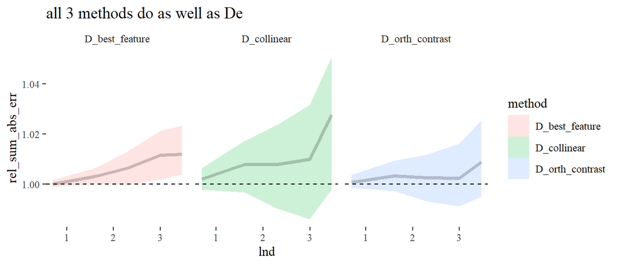

Figure 4.2: Comparing which model does the best job of predicting reaction times: log number of distractors plotted againt the absolute error of the model.

```r
Derr %>% ggplot(aes(lnd, rel_sum_abs_err, fill = method)) +
  stat_lineribbon(alpha = 0.2, .width = 0.97) +
  facet_wrap(~method) +
  geom_hline(yintercept = 1, linetype = 2) +
  ggtitle("all 3 methods do as well as De")
```